# Birth Data Report

Allison Young

September 22, 2018

## I.Setup

Loaded libraries and functions I’ve created to help with basic data analysis and dataset preview.

### Printed Summary of File

```r
textsummary(fname,births)
```

```
## [1] " smoking.csv : This file has 869 rows, and 12 columns"
## [1] "The varible names are id, date, gestation, bwt.oz, parity, mrace, mage, med, mht, mpregwt, inc, smoke"
```

### Explore Data

Explored diminsions of the file and summaries of variables.

```
## [1] " file : This file has 869 rows, and 12 columns"
## 'data.frame':    869 obs. of  12 variables:
##  $ id       : int  4604 7435 7722 2026 3553 3491 6757 6153 8187 8403 ...
##  $ date     : int  1598 1527 1563 1503 1638 1705 1444 1405 1669 1669 ...
##  $ gestation: int  148 181 204 225 233 234 234 235 236 241 ...
##  $ bwt.oz   : int  116 110 55 132 105 85 97 129 63 128 ...
##  $ parity   : int  7 7 11 4 4 7 0 3 0 0 ...
##  $ mrace    : int  7 7 7 7 7 7 6 7 5 7 ...
##  $ mage     : int  28 27 35 28 34 33 26 24 24 17 ...
##  $ med      : int  1 1 3 2 3 1 5 4 5 1 ...
##  $ mht      : int  66 64 65 67 61 67 65 66 58 64 ...
##  $ mpregwt  : int  135 133 140 148 130 130 112 135 99 126 ...
##  $ inc      : int  2 1 6 3 3 2 6 1 7 2 ...
##  $ smoke    : int  0 0 0 0 0 0 0 0 0 0 ...
## NULL
##        id            date        gestation         bwt.oz
##  Min.   :  15   Min.   :1350   Min.   :148.0   Min.   : 55.0
##  1st Qu.:5477   1st Qu.:1444   1st Qu.:272.0   1st Qu.:108.0
##  Median :6734   Median :1540   Median :279.0   Median :119.0
##  Mean   :6032   Mean   :1536   Mean   :278.5   Mean   :118.4
##  3rd Qu.:7587   3rd Qu.:1627   3rd Qu.:286.0   3rd Qu.:129.0
##  Max.   :9263   Max.   :1714   Max.   :338.0   Max.   :174.0
##      parity           mrace            mage            med
##  Min.   : 0.000   Min.   :0.000   Min.   :15.00   Min.   :0.000
##  1st Qu.: 1.000   1st Qu.:0.000   1st Qu.:23.00   1st Qu.:2.000
##  Median : 2.000   Median :2.000   Median :26.00   Median :2.000
##  Mean   : 1.953   Mean   :2.995   Mean   :27.29   Mean   :2.932
##  3rd Qu.: 3.000   3rd Qu.:7.000   3rd Qu.:31.00   3rd Qu.:4.000
##  Max.   :11.000   Max.   :9.000   Max.   :45.00   Max.   :7.000
##       mht           mpregwt           inc            smoke
##  Min.   :53.00   Min.   : 87.0   Min.   :0.000   Min.   :0.0000
##  1st Qu.:62.00   1st Qu.:113.0   1st Qu.:2.000   1st Qu.:0.0000
##  Median :64.00   Median :125.0   Median :3.000   Median :0.0000
##  Mean   :64.07   Mean   :128.5   Mean   :3.681   Mean   :0.4638
##  3rd Qu.:66.00   3rd Qu.:140.0   3rd Qu.:5.000   3rd Qu.:1.0000
##  Max.   :72.00   Max.   :220.0   Max.   :9.000   Max.   :1.0000
```

## II. Exploring Relationships

Outcome Variable: Birthweight (bwt)

First, I mapped a series of plots between birthweights and predictor variables, and looked at the relationship between birthweight and smoking. When looking at birthweight and smoking by race, there appeared to potentially be an interaction by race as well as a clear difference between some races, such as between black and white babies.

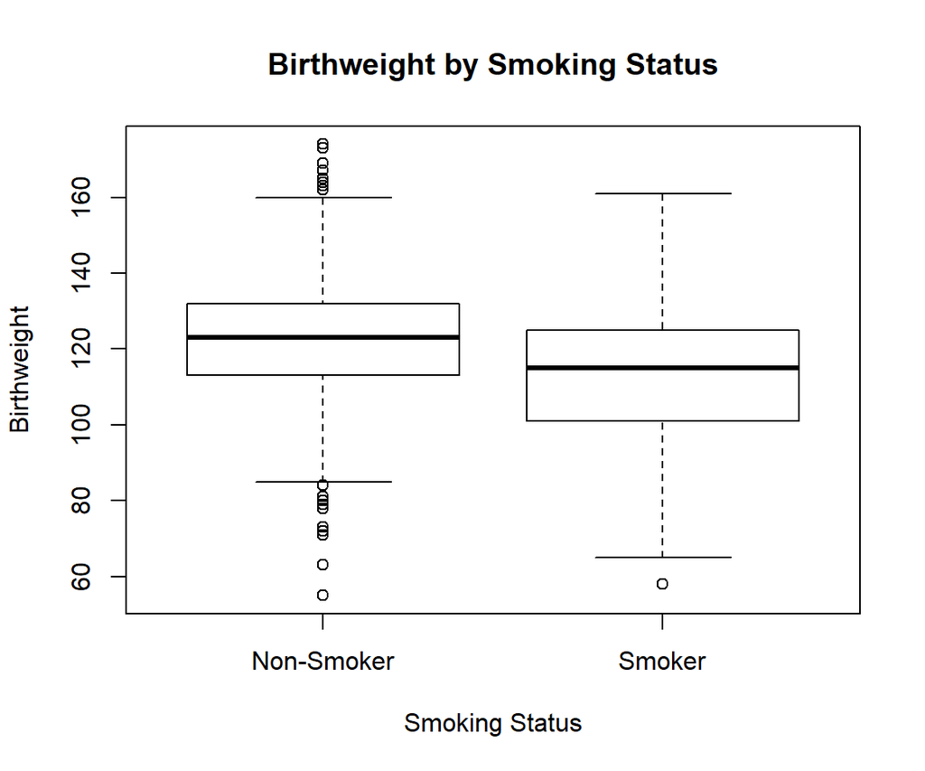

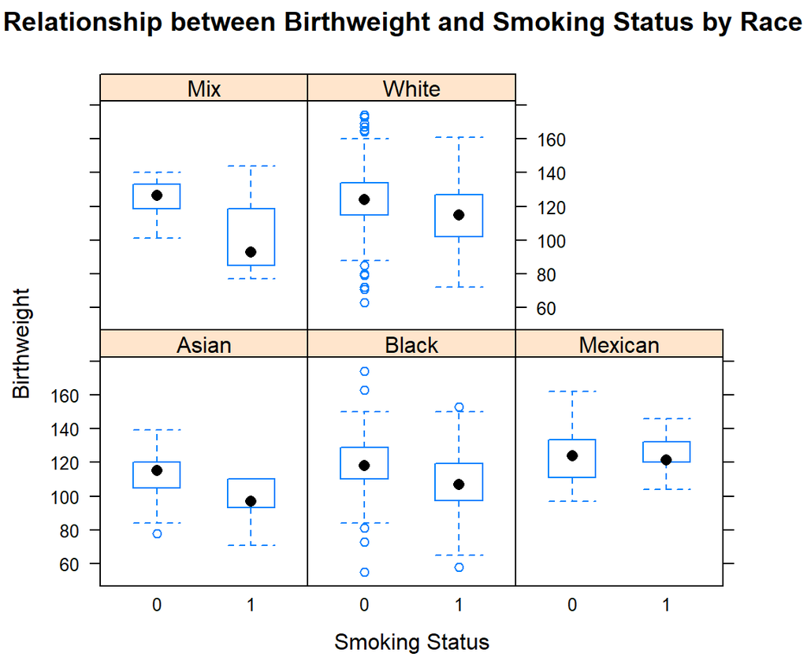

## Initial Modeling

After considering inital plots and a few initial models, I settled on the first model to plot out, and check residuals for, found below.

### Model 1 (with interaction)

Baseline Predictor Factors: Smoker= Non Smoker, Race= White Mother Mother Education = HS Grad Only Income = $10,000 - $12,499

Model Variables: Mother Age, Mother Height, Mother Pregnant Weight, Parity Date of Birth

Interaction: Mother Race(As Factor) * Smoke(As Factor)

```r
Mod1 <- lm(bwt~mageCent + mhtCent + mpregwtCent + dateCent+ parityCent + relevel(as.factor(medtxt), ref = "HS Grad Only")+ relevel(as.factor(inctxt), ref="10000-12499") +  relevel(as.factor(smoke), ref="0") * relevel(as.factor(mracetxt), ref="White"), data = births)
summary(Mod1)
```

```
##
## Call:
## lm(formula = bwt ~ mageCent + mhtCent + mpregwtCent + dateCent +
##     parityCent + relevel(as.factor(medtxt), ref = "HS Grad Only") +
##     relevel(as.factor(inctxt), ref = "10000-12499") + relevel(as.factor(smoke),
##     ref = "0") * relevel(as.factor(mracetxt), ref = "White"),
##     data = births)
##
## Residuals:
##     Min      1Q  Median      3Q     Max
## -66.050  -9.772  -0.282  10.290  48.605
##
## Coefficients:
##                                                                                            Estimate
## (Intercept)                                                                              125.259982
## mageCent                                                                                  -0.037103
## mhtCent                                                                                    1.046710
## mpregwtCent                                                                                0.106746
## dateCent                                                                                   0.012706
## parityCent                                                                                 0.769129
## relevel(as.factor(medtxt), ref = "HS Grad Only")8th to 12th, No Grad                      -2.742977
## relevel(as.factor(medtxt), ref = "HS Grad Only")College Grad                              -0.541865
## relevel(as.factor(medtxt), ref = "HS Grad Only")HS Grad and Trade                         -1.502135
## relevel(as.factor(medtxt), ref = "HS Grad Only")HS Grade and Some College                  0.431214
## relevel(as.factor(medtxt), ref = "HS Grad Only")Less than 8th Grade                       -9.904488
## relevel(as.factor(medtxt), ref = "HS Grad Only")Trade School (HSG Unknown)               -11.072093
## relevel(as.factor(inctxt), ref = "10000-12499")12500-14999                                -0.565441
## relevel(as.factor(inctxt), ref = "10000-12499")15000-17499                                -1.663774
## relevel(as.factor(inctxt), ref = "10000-12499")17500-19999                                -0.514136
## relevel(as.factor(inctxt), ref = "10000-12499")20000-22499                                 0.003081
## relevel(as.factor(inctxt), ref = "10000-12499")22500+                                     -4.367393
## relevel(as.factor(inctxt), ref = "10000-12499")2500-4999                                   0.940746
## relevel(as.factor(inctxt), ref = "10000-12499")5000-7499                                   2.679089
## relevel(as.factor(inctxt), ref = "10000-12499")7500-9999                                  -0.818641
## relevel(as.factor(inctxt), ref = "10000-12499")Under 2500                                 -2.089540
## relevel(as.factor(smoke), ref = "0")1                                                     -9.426709
## relevel(as.factor(mracetxt), ref = "White")Asian                                          -5.549252
## relevel(as.factor(mracetxt), ref = "White")Black                                         -10.259062
## relevel(as.factor(mracetxt), ref = "White")Mexican                                         0.584158
## relevel(as.factor(mracetxt), ref = "White")Mix                                            -0.423766
```

[output cut: 119 more lines]

```
## relevel(as.factor(smoke), ref = "0")1                                                    ***
## relevel(as.factor(mracetxt), ref = "White")Asian
## relevel(as.factor(mracetxt), ref = "White")Black                                         ***
## relevel(as.factor(mracetxt), ref = "White")Mexican
## relevel(as.factor(mracetxt), ref = "White")Mix
## relevel(as.factor(smoke), ref = "0")1:relevel(as.factor(mracetxt), ref = "White")Asian
## relevel(as.factor(smoke), ref = "0")1:relevel(as.factor(mracetxt), ref = "White")Black
## relevel(as.factor(smoke), ref = "0")1:relevel(as.factor(mracetxt), ref = "White")Mexican .
## relevel(as.factor(smoke), ref = "0")1:relevel(as.factor(mracetxt), ref = "White")Mix
## ---
## Signif. codes:  0 '***' 0.001 '**' 0.01 '*' 0.05 '.' 0.1 ' ' 1
##
## Residual standard error: 16.68 on 839 degrees of freedom
## Multiple R-squared:  0.1745, Adjusted R-squared:  0.146
## F-statistic: 6.117 on 29 and 839 DF,  p-value: < 2.2e-16
```

#### Model 1 Residuals by Predictor Variables

The residuals for this model look pretty good.

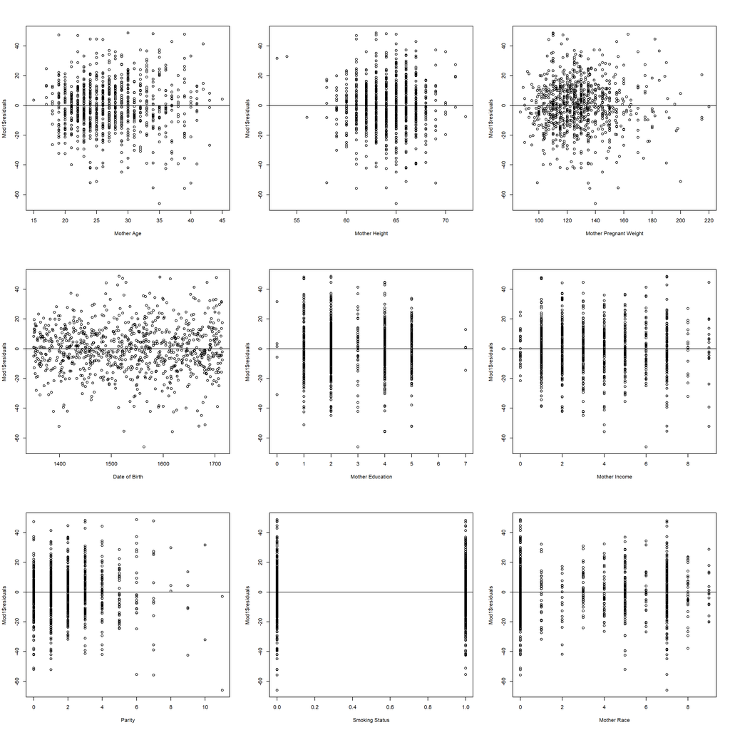

### Model 2 (without interaction)

I also created a second model without interaction and summarized it as well.

Baseline Predictor Factors: Smoker= Non Smoker, Race= White Mother Mother Education = HS Grad Only Income = $10,000 - $12,499

Model Variables: Mother Age, Mother Height, Mother Pregnant Weight, Parity Date of Birth

No Interaction

```r
Mod2 <- lm(bwt~mageCent + mhtCent + mpregwtCent + dateCent+ parityCent + relevel(as.factor(medtxt), ref = "HS Grad Only")+ relevel(as.factor(inctxt), ref="10000-12499") +  relevel(as.factor(smoke), ref="0") + relevel(as.factor(mracetxt), ref="White"), data = births)
summary(Mod2)
```

```
##
## Call:
## lm(formula = bwt ~ mageCent + mhtCent + mpregwtCent + dateCent +
##     parityCent + relevel(as.factor(medtxt), ref = "HS Grad Only") +
##     relevel(as.factor(inctxt), ref = "10000-12499") + relevel(as.factor(smoke),
##     ref = "0") + relevel(as.factor(mracetxt), ref = "White"),
##     data = births)
##
## Residuals:
##     Min      1Q  Median      3Q     Max
## -66.639  -9.423  -0.108  10.078  48.796
##
## Coefficients:
##                                                                              Estimate
## (Intercept)                                                                124.980651
## mageCent                                                                    -0.035073
## mhtCent                                                                      0.989393
## mpregwtCent                                                                  0.106565
## dateCent                                                                     0.013113
## parityCent                                                                   0.765674
## relevel(as.factor(medtxt), ref = "HS Grad Only")8th to 12th, No Grad        -2.365956
## relevel(as.factor(medtxt), ref = "HS Grad Only")College Grad                -0.384007
## relevel(as.factor(medtxt), ref = "HS Grad Only")HS Grad and Trade           -1.614469
## relevel(as.factor(medtxt), ref = "HS Grad Only")HS Grade and Some College    0.575002
## relevel(as.factor(medtxt), ref = "HS Grad Only")Less than 8th Grade         -7.574706
## relevel(as.factor(medtxt), ref = "HS Grad Only")Trade School (HSG Unknown) -11.765009
## relevel(as.factor(inctxt), ref = "10000-12499")12500-14999                  -0.643186
## relevel(as.factor(inctxt), ref = "10000-12499")15000-17499                  -1.641822
## relevel(as.factor(inctxt), ref = "10000-12499")17500-19999                  -0.472261
## relevel(as.factor(inctxt), ref = "10000-12499")20000-22499                  -0.027176
## relevel(as.factor(inctxt), ref = "10000-12499")22500+                       -4.673728
## relevel(as.factor(inctxt), ref = "10000-12499")2500-4999                     0.980664
## relevel(as.factor(inctxt), ref = "10000-12499")5000-7499                     2.525336
## relevel(as.factor(inctxt), ref = "10000-12499")7500-9999                    -0.755775
## relevel(as.factor(inctxt), ref = "10000-12499")Under 2500                   -2.076024
## relevel(as.factor(smoke), ref = "0")1                                       -9.010719
## relevel(as.factor(mracetxt), ref = "White")Asian                            -7.451374
## relevel(as.factor(mracetxt), ref = "White")Black                            -9.239311
## relevel(as.factor(mracetxt), ref = "White")Mexican                           3.879319
## relevel(as.factor(mracetxt), ref = "White")Mix                              -3.046525
```

[output cut: 99 more lines]

```
## relevel(as.factor(inctxt), ref = "10000-12499")2500-4999
## relevel(as.factor(inctxt), ref = "10000-12499")5000-7499
## relevel(as.factor(inctxt), ref = "10000-12499")7500-9999
## relevel(as.factor(inctxt), ref = "10000-12499")Under 2500
## relevel(as.factor(smoke), ref = "0")1                                      ***
## relevel(as.factor(mracetxt), ref = "White")Asian                           *
## relevel(as.factor(mracetxt), ref = "White")Black                           ***
## relevel(as.factor(mracetxt), ref = "White")Mexican
## relevel(as.factor(mracetxt), ref = "White")Mix
## ---
## Signif. codes:  0 '***' 0.001 '**' 0.01 '*' 0.05 '.' 0.1 ' ' 1
##
## Residual standard error: 16.71 on 843 degrees of freedom
## Multiple R-squared:  0.1681, Adjusted R-squared:  0.1434
## F-statistic: 6.814 on 25 and 843 DF,  p-value: < 2.2e-16
```

##### Model 2 Residuals by Predictor Variable

Plotted Variable residuals for Model 2 are similar to those of Model 1.

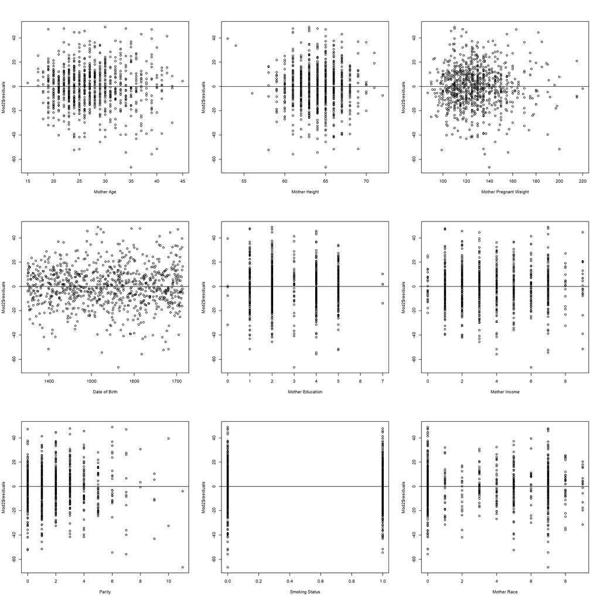

## Refining the Model

### Are these two models different? Nested F-test

```r
#summary(Mod1)
#summary(Mod2)
anova(Mod1,Mod2)
```

|  | Res.Df | RSS | Df | Sum of Sq | F | Pr(>F) |
| --- | --- | --- | --- | --- | --- | --- |
| 1 | 839 | 233459.6 | NA | NA | NA | NA |
| 2 | 843 | 235277.8 | -4 | -1818.209 | 1.633556 | 0.1637438 |

### Multicollinearity

I also looked at whether parity was highly correlated with mother’s age, and if so, if it could be removed from the model. Results showed that while there is a correlation (.5), it is not high enough to remove parity from the model.

```r
cor(births$mage,births$parity)
```

```
## [1] 0.5236904
```

After these two additional explorations, I feel good interpreting my selected model.

## Final Model Interpretation

```r
summary(Mod1)
```

```
##
## Call:
## lm(formula = bwt ~ mageCent + mhtCent + mpregwtCent + dateCent +
##     parityCent + relevel(as.factor(medtxt), ref = "HS Grad Only") +
##     relevel(as.factor(inctxt), ref = "10000-12499") + relevel(as.factor(smoke),
##     ref = "0") * relevel(as.factor(mracetxt), ref = "White"),
##     data = births)
##
## Residuals:
##     Min      1Q  Median      3Q     Max
## -66.050  -9.772  -0.282  10.290  48.605
##
## Coefficients:
##                                                                                            Estimate
## (Intercept)                                                                              125.259982
## mageCent                                                                                  -0.037103
## mhtCent                                                                                    1.046710
## mpregwtCent                                                                                0.106746
## dateCent                                                                                   0.012706
## parityCent                                                                                 0.769129
## relevel(as.factor(medtxt), ref = "HS Grad Only")8th to 12th, No Grad                      -2.742977
## relevel(as.factor(medtxt), ref = "HS Grad Only")College Grad                              -0.541865
## relevel(as.factor(medtxt), ref = "HS Grad Only")HS Grad and Trade                         -1.502135
## relevel(as.factor(medtxt), ref = "HS Grad Only")HS Grade and Some College                  0.431214
## relevel(as.factor(medtxt), ref = "HS Grad Only")Less than 8th Grade                       -9.904488
## relevel(as.factor(medtxt), ref = "HS Grad Only")Trade School (HSG Unknown)               -11.072093
## relevel(as.factor(inctxt), ref = "10000-12499")12500-14999                                -0.565441
## relevel(as.factor(inctxt), ref = "10000-12499")15000-17499                                -1.663774
## relevel(as.factor(inctxt), ref = "10000-12499")17500-19999                                -0.514136
## relevel(as.factor(inctxt), ref = "10000-12499")20000-22499                                 0.003081
## relevel(as.factor(inctxt), ref = "10000-12499")22500+                                     -4.367393
## relevel(as.factor(inctxt), ref = "10000-12499")2500-4999                                   0.940746
## relevel(as.factor(inctxt), ref = "10000-12499")5000-7499                                   2.679089
## relevel(as.factor(inctxt), ref = "10000-12499")7500-9999                                  -0.818641
## relevel(as.factor(inctxt), ref = "10000-12499")Under 2500                                 -2.089540
## relevel(as.factor(smoke), ref = "0")1                                                     -9.426709
## relevel(as.factor(mracetxt), ref = "White")Asian                                          -5.549252
## relevel(as.factor(mracetxt), ref = "White")Black                                         -10.259062
## relevel(as.factor(mracetxt), ref = "White")Mexican                                         0.584158
## relevel(as.factor(mracetxt), ref = "White")Mix                                            -0.423766
```

[output cut: 119 more lines]

```
## relevel(as.factor(smoke), ref = "0")1                                                    ***
## relevel(as.factor(mracetxt), ref = "White")Asian
## relevel(as.factor(mracetxt), ref = "White")Black                                         ***
## relevel(as.factor(mracetxt), ref = "White")Mexican
## relevel(as.factor(mracetxt), ref = "White")Mix
## relevel(as.factor(smoke), ref = "0")1:relevel(as.factor(mracetxt), ref = "White")Asian
## relevel(as.factor(smoke), ref = "0")1:relevel(as.factor(mracetxt), ref = "White")Black
## relevel(as.factor(smoke), ref = "0")1:relevel(as.factor(mracetxt), ref = "White")Mexican .
## relevel(as.factor(smoke), ref = "0")1:relevel(as.factor(mracetxt), ref = "White")Mix
## ---
## Signif. codes:  0 '***' 0.001 '**' 0.01 '*' 0.05 '.' 0.1 ' ' 1
##
## Residual standard error: 16.68 on 839 degrees of freedom
## Multiple R-squared:  0.1745, Adjusted R-squared:  0.146
## F-statistic: 6.117 on 29 and 839 DF,  p-value: < 2.2e-16
```

### Important Predictive Factors

#### Smoking Status

Holding all other factors constant, we are 95% confident that the true mean difference between a smoking and non-smoking mother (White) is between CI[-12.11, -6.74], with a point estimate of -9.427 oz.

### Other Trends

#### Increasing Birthweight over Time

```r
coef(Mod1)
```

```
##                                                                              (Intercept)
##                                                                            125.259982175
##                                                                                 mageCent
##                                                                             -0.037102503
##                                                                                  mhtCent
##                                                                              1.046709551
##                                                                              mpregwtCent
##                                                                              0.106746387
##                                                                                 dateCent
##                                                                              0.012706261
##                                                                               parityCent
##                                                                              0.769129036
##                     relevel(as.factor(medtxt), ref = "HS Grad Only")8th to 12th, No Grad
##                                                                             -2.742977404
##                             relevel(as.factor(medtxt), ref = "HS Grad Only")College Grad
##                                                                             -0.541864726
##                        relevel(as.factor(medtxt), ref = "HS Grad Only")HS Grad and Trade
##                                                                             -1.502134567
##                relevel(as.factor(medtxt), ref = "HS Grad Only")HS Grade and Some College
##                                                                              0.431214223
##                      relevel(as.factor(medtxt), ref = "HS Grad Only")Less than 8th Grade
##                                                                             -9.904488409
##               relevel(as.factor(medtxt), ref = "HS Grad Only")Trade School (HSG Unknown)
##                                                                            -11.072092881
##                               relevel(as.factor(inctxt), ref = "10000-12499")12500-14999
##                                                                             -0.565440938
##                               relevel(as.factor(inctxt), ref = "10000-12499")15000-17499
##                                                                             -1.663774019
##                               relevel(as.factor(inctxt), ref = "10000-12499")17500-19999
##                                                                             -0.514136035
##                               relevel(as.factor(inctxt), ref = "10000-12499")20000-22499
##                                                                              0.003081433
##                                    relevel(as.factor(inctxt), ref = "10000-12499")22500+
##                                                                             -4.367392710
##                                 relevel(as.factor(inctxt), ref = "10000-12499")2500-4999
##                                                                              0.940745511
##                                 relevel(as.factor(inctxt), ref = "10000-12499")5000-7499
##                                                                              2.679088674
##                                 relevel(as.factor(inctxt), ref = "10000-12499")7500-9999
##                                                                             -0.818641138
##                                relevel(as.factor(inctxt), ref = "10000-12499")Under 2500
##                                                                             -2.089539605
##                                                    relevel(as.factor(smoke), ref = "0")1
##                                                                             -9.426709018
##                                         relevel(as.factor(mracetxt), ref = "White")Asian
##                                                                             -5.549252224
##                                         relevel(as.factor(mracetxt), ref = "White")Black
##                                                                            -10.259062015
##                                       relevel(as.factor(mracetxt), ref = "White")Mexican
##                                                                              0.584158187
##                                           relevel(as.factor(mracetxt), ref = "White")Mix
##                                                                             -0.423765774
##   relevel(as.factor(smoke), ref = "0")1:relevel(as.factor(mracetxt), ref = "White")Asian
##                                                                             -6.852601809
##   relevel(as.factor(smoke), ref = "0")1:relevel(as.factor(mracetxt), ref = "White")Black
##                                                                              2.436905082
## relevel(as.factor(smoke), ref = "0")1:relevel(as.factor(mracetxt), ref = "White")Mexican
##                                                                             14.286891493
##     relevel(as.factor(smoke), ref = "0")1:relevel(as.factor(mracetxt), ref = "White")Mix
##                                                                            -13.461402379
```

```r
confint(Mod1)
```

```
##                                                                                                  2.5 %
## (Intercept)                                                                              121.444193977
## mageCent                                                                                  -0.299911882
## mhtCent                                                                                    0.515457198
## mpregwtCent                                                                                0.042231229
## dateCent                                                                                   0.002007306
## parityCent                                                                                -0.018338054
## relevel(as.factor(medtxt), ref = "HS Grad Only")8th to 12th, No Grad                      -6.401834766
## relevel(as.factor(medtxt), ref = "HS Grad Only")College Grad                              -3.935449036
## relevel(as.factor(medtxt), ref = "HS Grad Only")HS Grad and Trade                         -6.721064695
## relevel(as.factor(medtxt), ref = "HS Grad Only")HS Grade and Some College                 -2.602672487
## relevel(as.factor(medtxt), ref = "HS Grad Only")Less than 8th Grade                      -25.180461259
## relevel(as.factor(medtxt), ref = "HS Grad Only")Trade School (HSG Unknown)               -27.718510658
## relevel(as.factor(inctxt), ref = "10000-12499")12500-14999                                -5.225222841
## relevel(as.factor(inctxt), ref = "10000-12499")15000-17499                                -7.134272744
## relevel(as.factor(inctxt), ref = "10000-12499")17500-19999                                -5.065825065
## relevel(as.factor(inctxt), ref = "10000-12499")20000-22499                                -8.936662092
## relevel(as.factor(inctxt), ref = "10000-12499")22500+                                    -12.425648790
## relevel(as.factor(inctxt), ref = "10000-12499")2500-4999                                  -3.374215074
## relevel(as.factor(inctxt), ref = "10000-12499")5000-7499                                  -1.586216728
## relevel(as.factor(inctxt), ref = "10000-12499")7500-9999                                  -5.116612598
## relevel(as.factor(inctxt), ref = "10000-12499")Under 2500                                 -9.405362251
## relevel(as.factor(smoke), ref = "0")1                                                    -12.113078072
## relevel(as.factor(mracetxt), ref = "White")Asian                                         -12.681741692
## relevel(as.factor(mracetxt), ref = "White")Black                                         -14.404239625
## relevel(as.factor(mracetxt), ref = "White")Mexican                                        -7.284520317
## relevel(as.factor(mracetxt), ref = "White")Mix                                           -10.165506674
## relevel(as.factor(smoke), ref = "0")1:relevel(as.factor(mracetxt), ref = "White")Asian   -19.997361489
## relevel(as.factor(smoke), ref = "0")1:relevel(as.factor(mracetxt), ref = "White")Black    -3.376174824
## relevel(as.factor(smoke), ref = "0")1:relevel(as.factor(mracetxt), ref = "White")Mexican  -1.746082477
## relevel(as.factor(smoke), ref = "0")1:relevel(as.factor(mracetxt), ref = "White")Mix     -34.925847653
##                                                                                                97.5 %
## (Intercept)                                                                              129.07577037
## mageCent                                                                                   0.22570688
## mhtCent                                                                                    1.57796190
## mpregwtCent                                                                                0.17126155
## dateCent                                                                                   0.02340522
## parityCent                                                                                 1.55659613
## relevel(as.factor(medtxt), ref = "HS Grad Only")8th to 12th, No Grad                       0.91587996
## relevel(as.factor(medtxt), ref = "HS Grad Only")College Grad                               2.85171958
## relevel(as.factor(medtxt), ref = "HS Grad Only")HS Grad and Trade                          3.71679556
```

[output cut: 21 more lines]